# Basemap

## Basemap

Basemap is a library for plotting 2D data on maps in Python. You can find documentation on Basemap at the following sites: (official documention [here](http://matplotlib.org/basemap/index.html), unofficial documentation [here](http://basemaptutorial.readthedocs.io/en/latest/index.html) )

To install it, open your terminal and run:

`conda install basemap`

If this doesn't work then you can you use [conda forge basemap](https://github.com/conda-forge/basemap-feedstock), and [conda forge basemap-data-hires](https://github.com/conda-forge/basemap-data-hires-feedstock) and follow the directions.

```python
import matplotlib.pyplot as plt
import warnings
from mpl_toolkits.basemap import Basemap
warnings.filterwarnings("ignore")
%matplotlib inline
```

To draw our first map, we simply do the following:

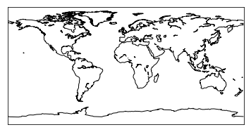

```python
map = Basemap()
map.drawcoastlines()
```

The default projection is the [Equirectangular projection](https://en.wikipedia.org/wiki/Equirectangular_projection) but you can change it to another projection:

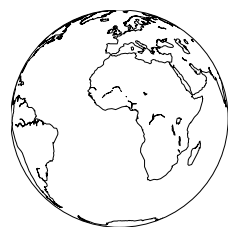

```python
map = Basemap(projection='ortho', lat_0=0, lon_0=0)
map.drawcoastlines()
```

`lat_0` and `lon_0` sets the center of the map. Changing it allows us to see the other parts of the earth.

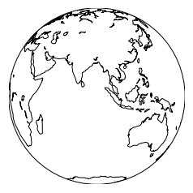

```python
map = Basemap(projection='ortho', lat_0=0, lon_0=90)
map.drawcoastlines()
```

To fill in the continents and oceans with some colors you can do the following:

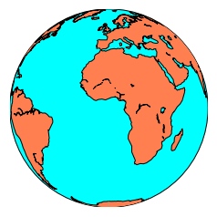

```python
map = Basemap(projection='ortho', lat_0=0, lon_0=0)
map.drawmapboundary(fill_color='aqua')
map.fillcontinents(color='coral',lake_color='aqua')
map.drawcoastlines()
```

You can add country lines as well:

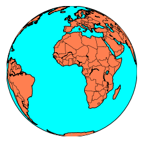

```python
map = Basemap(projection='ortho', lat_0=0, lon_0=0)
map.drawmapboundary(fill_color='aqua')
map.fillcontinents(color='coral',lake_color='aqua')
map.drawcoastlines()
map.drawcountries()
```

The map is essentially a matplotlib object, so you can use matplotlib's methods to access it. For example, to draw some points on the map you can use the following:

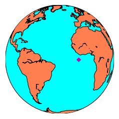

```python
map = Basemap(projection='ortho', lat_0=0, lon_0=-30)
map.drawmapboundary(fill_color='aqua')
map.fillcontinents(color='coral',lake_color='aqua')
map.drawcoastlines()
x, y = map(-10, 0) #x=longitude, y=latitude
map.plot(x, y, marker='D',color='m')
```

You can add text and label a city by using the text function.

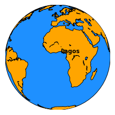

```python
map = Basemap(projection='ortho',
              lat_0=0, lon_0=0)

map.drawmapboundary(fill_color='dodgerblue')
map.fillcontinents(color='orange',lake_color='dodgerblue')
map.drawcoastlines()

lon = 3.4
lat = 3.4

x, y = map(lon, lat)

plt.text(x, y, 'Lagos',fontsize=12,fontweight='bold',
                    ha='left',va='bottom',color='k')

plt.show()
```

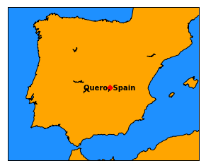

```python
map = Basemap(llcrnrlon=-10.5,llcrnrlat=35,urcrnrlon=4.,urcrnrlat=44.,
             resolution='i', projection='tmerc', lat_0 = 39.5, lon_0 = -3.25)

map.drawmapboundary(fill_color='dodgerblue')
map.fillcontinents(color='orange',lake_color='dodgerblue')
map.drawcoastlines()
lon = -3.25
lat = 39.5

x, y = map(lon, lat)
plt.text(x, y, 'Quero, Spain',fontsize=10,fontweight='bold',
                    ha='center',va='center',color='k')
map.plot(x, y, marker='D',color='r')

plt.show()
```

There are a few different options for adding more detailed topography to the Earth's surface on your map. You can create a map using [NASA's blue marble](https://earthobservatory.nasa.gov/Features/BlueMarble/BlueMarble_history.php) model.

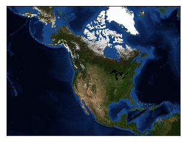

```python
m = Basemap(width=12000000,height=9000000,projection='lcc',
            resolution=None,lat_1=45.,lat_2=55,lat_0=50,lon_0=-107.)
m.bluemarble()
plt.show()
```

You can also create a [shaded relief map](https://en.wikipedia.org/wiki/Terrain_cartography#Shaded_relief)

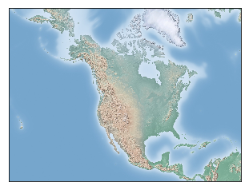

```python
m = Basemap(width=12000000,height=9000000,projection='lcc',
            resolution=None,lat_1=45.,lat_2=55,lat_0=50,lon_0=-107.)
m.shadedrelief()
plt.show()
```

or you can create an [etopo relief map](https://www.ngdc.noaa.gov/mgg/global/global.html)

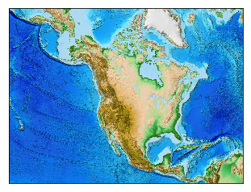

```python
m = Basemap(width=12000000,height=9000000,projection='lcc',
            resolution=None,lat_1=45.,lat_2=55,lat_0=50,lon_0=-107.)
m.etopo()
plt.show()
```